# CLUSTERING

Alejandro Pinto

2024-11-24

La base de datos ‘Internet.xlsx’ contiene diferentes indicadores sobre el uso y la tenencia de radio, tv, teléfono fijo, etc, en diferentes países como se describe en la siguiente tabla:

```r
df = read_excel("Internet.xlsx"); head(df)
```

| Country | Radio | TV | Telephone | Mobile | Computer | Internet | Computer_ind | Internet_ind | Mobil_ind |
| --- | --- | --- | --- | --- | --- | --- | --- | --- | --- |
| Afghanistan | 98.9 | 81.7 | 27.7 | 90.7 | 27.7 | 55.2 | 6.1 | 55.7 | 73.7 |
| Albania | 42.0 | 99.3 | 17.1 | 86.6 | 20.2 | 83.3 | 27.2 | 72.2 | 75.6 |
| Algeria | 52.6 | 99.0 | 27.7 | 99.1 | 42.2 | 74.4 | 33.3 | 49.0 | 91.7 |
| Andorra | 72.6 | 98.7 | 74.9 | 97.9 | 85.7 | 94.5 | 70.7 | 91.6 | 86.1 |
| Angola | 16.4 | 22.9 | 32.6 | 62.8 | 32.2 | 6.7 | 59.3 | 62.5 | 51.4 |
| Argentina | 57.6 | 93.8 | 14.8 | 90.7 | 64.3 | 75.9 | 44.8 | 74.3 | 81.2 |

# Calcular la matriz de distancia (Euclidiana):

```r
Z <- df %>%
  select(-Country) %>%
  mutate(across(everything(), ~ scale(.) %>% as.vector()))

D <- dist(Z, method = "euclidean")
```

1. Realice un análsis de conglomerados jerárquico determinando el número de grupos (k = 2, 3, 4, 5, 6) y el método (Single, Complete, Centroid o Ward) de agrupamiento adecuado:

Métodos jerárquicos:

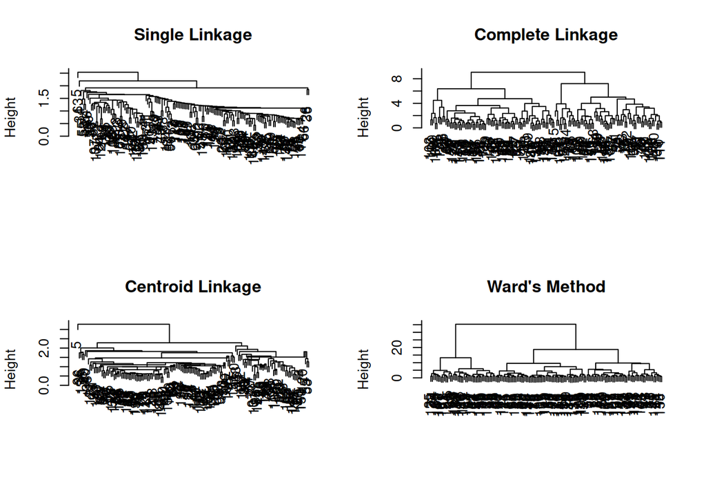

```r
agjers <- hclust(D, method = "single")
agjercom <- hclust(D, method = "complete")
agjercen <- hclust(D, method = "centroid")
agjerward <- hclust(D, method = "ward.D2")

# Visualización de los dendrogramas
par(mfrow = c(2, 2))
plot(agjers, main = "Single Linkage", xlab = "", sub = "")
plot(agjercom, main = "Complete Linkage", xlab = "", sub = "")
plot(agjercen, main = "Centroid Linkage", xlab = "", sub = "")
plot(agjerward, main = "Ward's Method", xlab = "", sub = "")
```

El método Ward minimiza la varianza dentro de los clusters, lo que generalmente produce resultados más equilibrados. Ahora se determina el número óptimo de clusters (método del codo y silhouette):

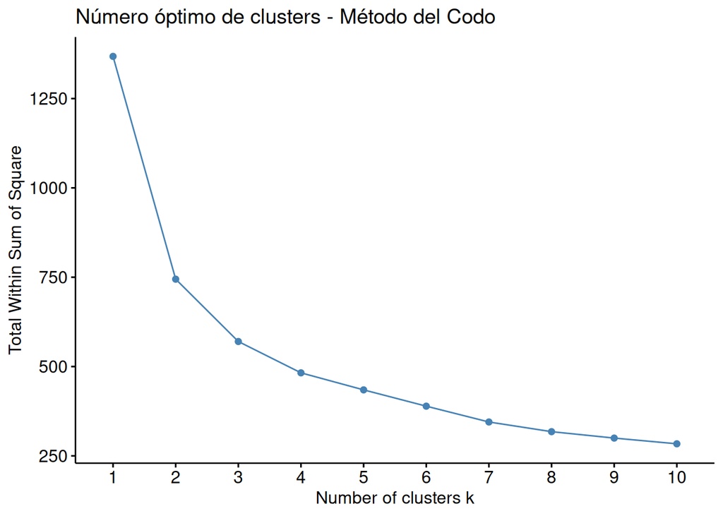

```r
fviz_nbclust(Z, FUN = hcut, method = "wss") +
  ggtitle("Número óptimo de clusters - Método del Codo")
```

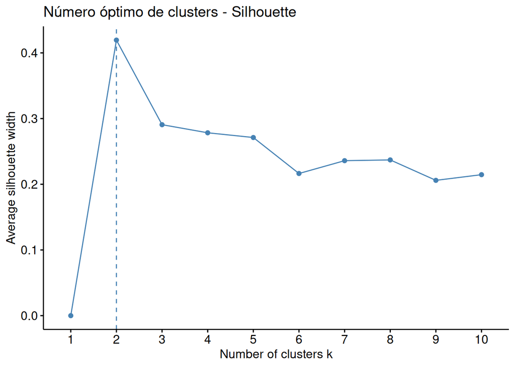

```r
fviz_nbclust(Z, FUN = hcut, method = "silhouette") +
  ggtitle("Número óptimo de clusters - Silhouette")
```

Los Gràficos muestran que el valor optimo de k = 2. Revisando un dendograma, cortamos el dendrograma en k=2:

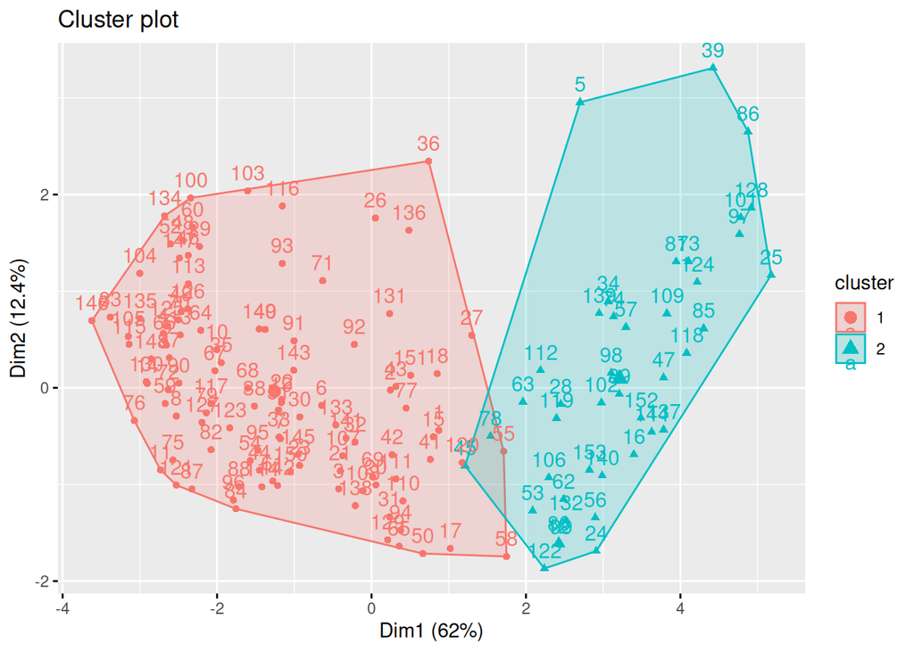

```r
k <- 2
clusters <- cutree(agjerward, k = k)
dfTotal <- df %>%
  mutate(Cluster = clusters)
fviz_cluster(list(data = Z, cluster = clusters))
```

2. Realice un análsis de conglomerados con el método de las k medias determinando el número de grupos adecuado:

Comenzamos con el método del Codo para encontrar el mejor k

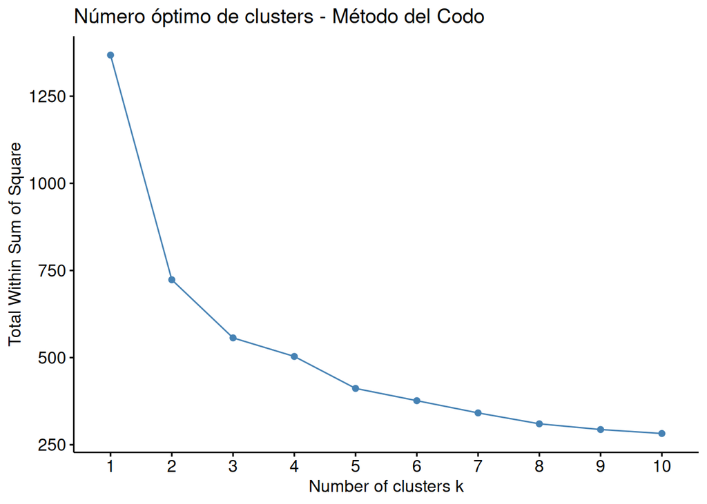

```r
fviz_nbclust(Z, kmeans, method = "wss") +
  ggtitle("Número óptimo de clusters - Método del Codo")
```

Luego revisamosel método del Silhouette para encontrar el mejor k

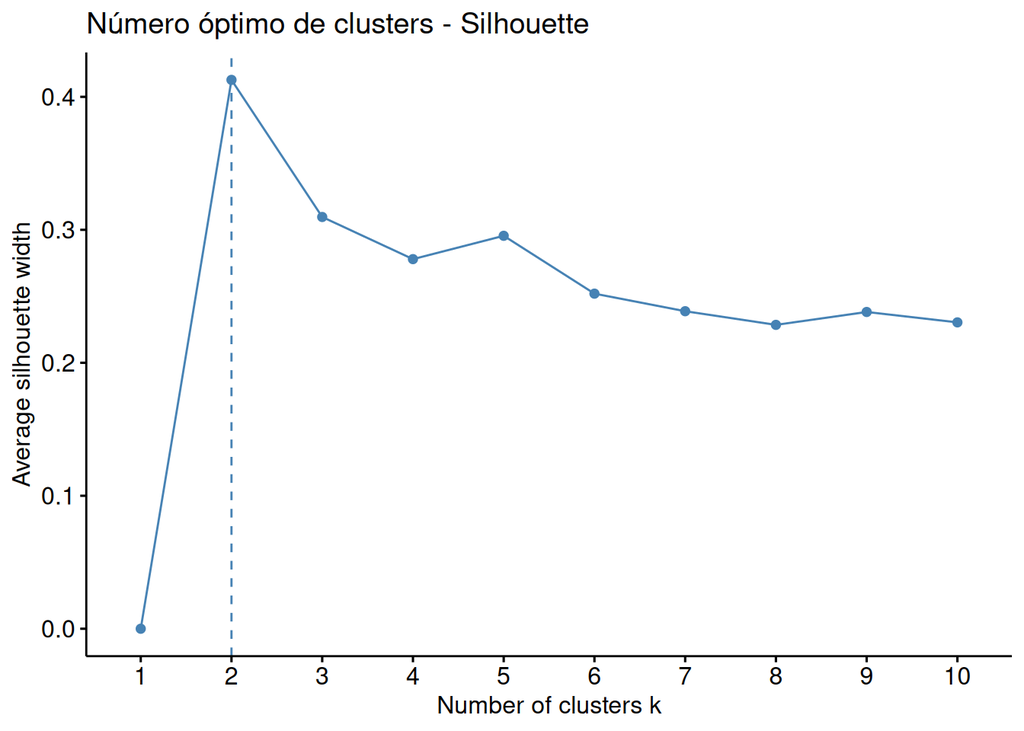

```r
fviz_nbclust(Z, kmeans, method = "silhouette") +
  ggtitle("Número óptimo de clusters - Silhouette")
```

Ejecutamos k-means con el k óptimo

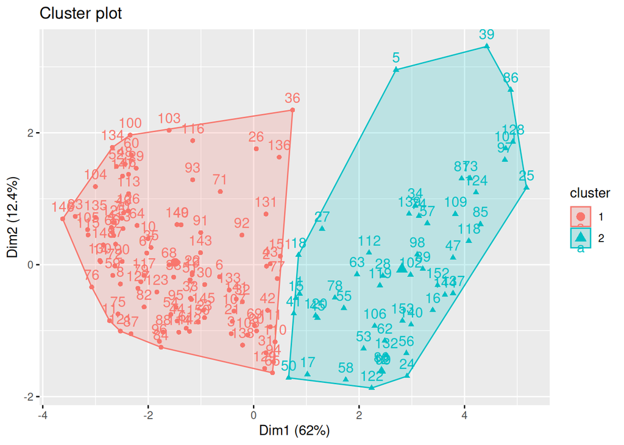

```r
set.seed(123)
k_optimo <- 2
modelo_kmeans <- kmeans(Z, centers = k_optimo, nstart = 25)

# Visualización de los clusters
fviz_cluster(modelo_kmeans, data = Z)
```

3. Qué método entre jerárquico y k-medias resultó mejor?

Segùn los gràficos anteriores, el metodo jeràrquico y el metodo kmeans arrojan los mismo valores, es decir sugieren un k=2 Ward. Igualmente se revisa el el valor pormedio que arroja cada mètodo:

```r
# Índice Silhouette para método jerárquico
clusters_jerarquico <- cutree(agjerward, k = 3)
silhouette_jerarquico <- silhouette(clusters_jerarquico, dist(Z))
summary(silhouette_jerarquico)
```

```
## Silhouette of 153 units in 3 clusters from silhouette.default(x = clusters_jerarquico, dist = dist(Z)) :
##  Cluster sizes and average silhouette widths:
##        50        60        43
## 0.1715465 0.3703138 0.3180427
## Individual silhouette widths:
##    Min. 1st Qu.  Median    Mean 3rd Qu.    Max.
## -0.2267  0.1838  0.3193  0.2907  0.4287  0.5336
```

```r
# Índice Silhouette para k-medias (con k=3 por ejemplo)
silhouette_kmeans <- silhouette(modelo_kmeans$cluster, dist(Z))
summary(silhouette_kmeans)
```

```
## Silhouette of 153 units in 2 clusters from silhouette.default(x = modelo_kmeans$cluster, dist = dist(Z)) :
##  Cluster sizes and average silhouette widths:
##       100        53
## 0.4354434 0.3698745
## Individual silhouette widths:
##      Min.   1st Qu.    Median      Mean   3rd Qu.      Max.
## -0.006238  0.340684  0.465204  0.412730  0.532679  0.607825
```

Se comparan los promedio:

```r
mean(silhouette_jerarquico[, 3])
```

```
## [1] 0.2906666
```

```r
mean(silhouette_kmeans[, 3])
```

```
## [1] 0.41273
```

4. Caracterice los grupos resultantes en (a) y (b) mediante medidas descriptivas (¯x, cv, Q1, Q3) y diagramas de cajas. ¾Se observan diferencias entre los agrupamientos realizados con ambos métodos?

Caracterizamos los clusters Método jerárquico:

```r
  clusters_jerarquico <- cutree(agjerward, k = 3)  # Cambia k según corresponda
  datos_jerarquico <- Z %>%
    mutate(Cluster = clusters_jerarquico) %>%
    group_by(Cluster) %>%
    summarise(across(everything(), list(
      Media = mean,
      CV = ~ sd(.) / mean(.),
      Q1 = ~ quantile(., 0.25),
      Q3 = ~ quantile(., 0.75)
    ))); datos_jerarquico
```

| Cluster | Radio_Media | Radio_CV | Radio_Q1 | Radio_Q3 | TV_Media | TV_CV | TV_Q1 | TV_Q3 | Telephone_Media | Telephone_CV | Telephone_Q1 | Telephone_Q3 | Mobile_Media | Mobile_CV | Mobile_Q1 | Mobile_Q3 | Computer_Media | Computer_CV | Computer_Q1 | Computer_Q3 | Internet_Media | Internet_CV | Internet_Q1 | Internet_Q3 | Computer_ind_Media | Computer_ind_CV | Computer_ind_Q1 | Computer_ind_Q3 | Internet_ind_Media | … |
| --- | --- | --- | --- | --- | --- | --- | --- | --- | --- | --- | --- | --- | --- | --- | --- | --- | --- | --- | --- | --- | --- | --- | --- | --- | --- | --- | --- | --- | --- | --- |
| 1 | -0.2488176 | -4.439003 | -1.1247261 | 0.4947661 | 0.4143813 | 1.0844272 | 0.2002811 | 0.7384687 | -0.1899399 | -4.5774582 | -0.80262872 | -0.06349464 | 0.3222174 | 1.0830310 | 0.06677438 | 0.593610020 | -0.2841643 | -1.8365680 | -0.6022707 | -0.07936709 | 0.02208748 | 28.1838743 | -0.3004087 | 0.4409975 | -0.295936 | -1.9901249 | -0.6746898 | 0.01039461 | 0.1518704 | … |
| 2 | 0.4050271 | 2.389372 | 0.1291757 | 0.8970203 | 0.6499514 | 0.3520787 | 0.6183915 | 0.7877090 | 0.7855122 | 1.0480535 | -0.01416512 | 1.49321554 | 0.5039447 | 0.5582849 | 0.36841361 | 0.701043170 | 1.0632622 | 0.3225469 | 0.8161155 | 1.33255358 | 0.89607816 | 0.2998511 | 0.7535358 | 1.0730540 | 1.007670 | 0.4391201 | 0.7985913 | 1.33425041 | 0.8693837 | … |
| 3 | -0.2758314 | -2.548659 | -0.7015212 | 0.2664030 | -1.3887476 | -0.5229650 | -1.9455585 | -0.8467228 | -0.8752031 | -0.3158344 | -1.01369437 | -0.91018325 | -1.0778499 | -1.2060885 | -2.25750052 | 0.002727689 | -1.1531981 | -0.2182870 | -1.3312647 | -1.04839563 | -1.27602474 | -0.3925135 | -1.6250130 | -1.1038572 | -1.061940 | -0.4515444 | -1.3615220 | -0.87042827 | -1.3896870 | … |

Caracterizamos los clusters - Método kMeans:

```r
  datos_kmeans <- Z %>%
    mutate(Cluster = modelo_kmeans$cluster) %>%
    group_by(Cluster) %>%
    summarise(across(everything(), list(
      Media = mean,
      CV = ~ sd(.) / mean(.),
      Q1 = ~ quantile(., 0.25),
      Q3 = ~ quantile(., 0.75)
    ))); datos_kmeans
```

| Cluster | Radio_Media | Radio_CV | Radio_Q1 | Radio_Q3 | TV_Media | TV_CV | TV_Q1 | TV_Q3 | Telephone_Media | Telephone_CV | Telephone_Q1 | Telephone_Q3 | Mobile_Media | Mobile_CV | Mobile_Q1 | Mobile_Q3 | Computer_Media | Computer_CV | Computer_Q1 | Computer_Q3 | Internet_Media | Internet_CV | Internet_Q1 | Internet_Q3 | Computer_ind_Media | Computer_ind_CV | Computer_ind_Q1 | Computer_ind_Q3 | Internet_ind_Media | … |
| --- | --- | --- | --- | --- | --- | --- | --- | --- | --- | --- | --- | --- | --- | --- | --- | --- | --- | --- | --- | --- | --- | --- | --- | --- | --- | --- | --- | --- | --- | --- |
| 1 | 0.07080693 | 14.780696 | -0.8125601 | 0.8352157 | 0.6216397 | 0.3973804 | 0.5423714 | 0.7842535 | 0.4570692 | 2.0610746 | -0.4104186 | 1.4641030 | 0.4501454 | 0.6937822 | 0.2713106 | 0.6865810 | 0.5596907 | 1.342521 | -0.1165442 | 1.1886945 | 0.5902404 | 0.9419288 | 0.3510361 | 1.0172159 | 0.5302199 | 1.4514162 | -0.05601664 | 1.0965680 | 0.6263444 | … |
| 2 | -0.13359798 | -6.736302 | -0.6114330 | 0.3271602 | -1.1729050 | -0.6934771 | -1.8315284 | -0.6635835 | -0.8623948 | -0.3147902 | -1.0072249 | -0.9101832 | -0.8493310 | -1.4950991 | -2.0674265 | 0.1804056 | -1.0560201 | -0.312834 | -1.3167171 | -0.9190841 | -1.1136611 | -0.5682930 | -1.6048492 | -0.8975664 | -1.0004149 | -0.4843918 | -1.34579299 | -0.7096431 | -1.1817819 | … |

Realizamos un diagrama de cajas para jerárquico:

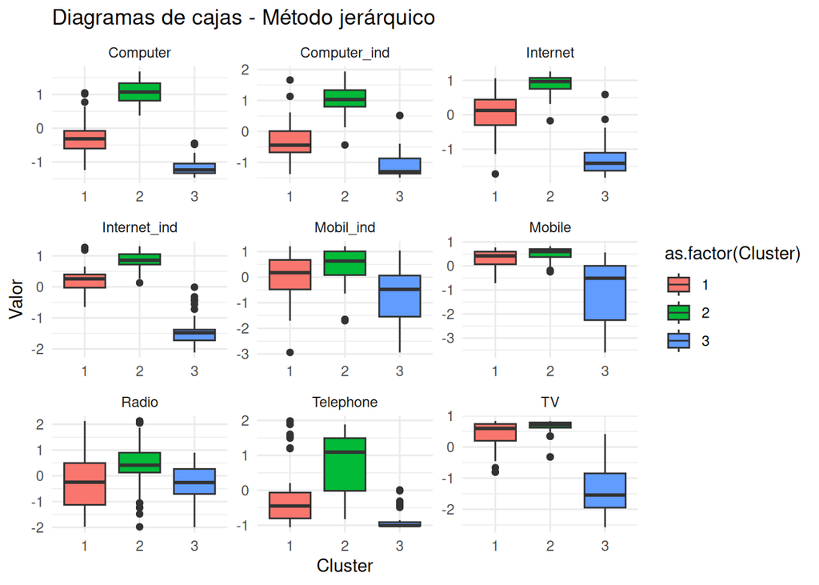

```r
  datos_jerarquico_boxplot <- Z %>%
    mutate(Cluster = clusters_jerarquico) %>%
    pivot_longer(cols = -Cluster, names_to = "Variable", values_to = "Valor")

  ggplot(datos_jerarquico_boxplot, aes(x = as.factor(Cluster), y = Valor, fill = as.factor(Cluster))) +
    geom_boxplot() +
    facet_wrap(~ Variable, scales = "free") +
    labs(title = "Diagramas de cajas - Método jerárquico", x = "Cluster", y = "Valor") +
    theme_minimal()
```

Ahora realizamos el diagrama de cajas para k-means:

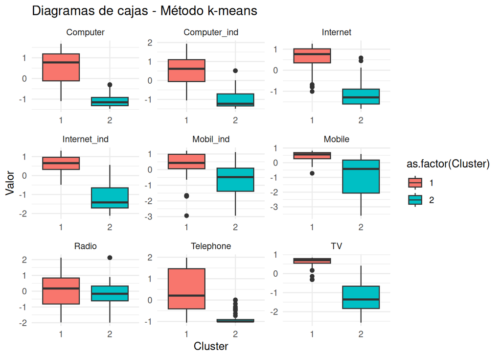

```r
  datos_kmeans_boxplot <- Z %>%
    mutate(Cluster = modelo_kmeans$cluster) %>%
    pivot_longer(cols = -Cluster, names_to = "Variable", values_to = "Valor")

  ggplot(datos_kmeans_boxplot, aes(x = as.factor(Cluster), y = Valor, fill = as.factor(Cluster))) +
    geom_boxplot() +
    facet_wrap(~ Variable, scales = "free") +
    labs(title = "Diagramas de cajas - Método k-means", x = "Cluster", y = "Valor") +
    theme_minimal()
```